# Human Activity Recognition

Deepanshu Rustagi

7/19/2020

# Introduction

Using devices such as Jawbone Up, Nike FuelBand, and Fitbit it is now possible to collect a large amount of data about personal activity relatively inexpensively. These type of devices are part of the quantified self movement - a group of enthusiasts who take measurements about themselves regularly to improve their health, to find patterns in their behavior, or because they are tech geeks. One thing that people regularly do is quantify how much of a particular activity they do, but they rarely quantify how well they do it. In this project, our goal will be to use data from accelerometers on the belt, forearm, arm, and dumbell of 6 participants. They were asked to perform barbell lifts correctly and incorrectly in 5 different ways. More information is available from the website here: http://web.archive.org/web/20161224072740/http:/groupware.les.inf.puc-rio.br/har

### Data Descriptions

The training data for this project are available here:

https://d396qusza40orc.cloudfront.net/predmachlearn/pml-training.csv

The test data are available here:

https://d396qusza40orc.cloudfront.net/predmachlearn/pml-testing.csv

The data for this project come from this source: http://web.archive.org/web/20161224072740/http:/groupware.les.inf.puc-rio.br/har.

# Loading Necessary Packages

```r
library(caret)
library(ggplot2)
library(rpart)
library(rpart.plot)
library(randomForest)
library(gbm)
```

# Data Loading

```r
mlatrainurl<-'https://d396qusza40orc.cloudfront.net/predmachlearn/pml-training.csv'
mlatesturl<-'https://d396qusza40orc.cloudfront.net/predmachlearn/pml-testing.csv'

download.file(mlatrainurl,'traindata.csv',method = 'curl')
download.file(mlatesturl,'testdata.csv',method = 'curl')

traindata<-read.csv('traindata.csv')
testdata<-read.csv('testdata.csv')
```

Checking the dimensions of the loaded data.

```r
dim(traindata)
```

```
## [1] 19622   160
```

```r
dim(testdata)
```

```
## [1]  20 160
```

# Data Cleansing

Out of 160 columns in the training data, those with near zero variance are removed.

```r
traindata<-traindata[,-nearZeroVar(traindata)]
```

Columns with more than 95% NA or missing values are removed.

```r
traindata<-traindata[,-(which(colMeans(is.na(traindata))>0.95))]
```

First 7 columns which are non-numeric and hance, won’t contribute to prediction, are removed.

```r
traindata<-traindata[,8:59]
```

Similar cleanising is done on testing data. Removing near zero variance and non-numeric first 7 columns.

```r
testdata<-testdata[,-nearZeroVar(testdata)]
testdata<-testdata[,8:59]
```

Comparing names of remaining training and testing data shows that last column is different. It is classe for training data and problem_id for testing data.

```r
names(traindata)==names(testdata)
```

```
##  [1]  TRUE  TRUE  TRUE  TRUE  TRUE  TRUE  TRUE  TRUE  TRUE  TRUE  TRUE  TRUE
## [13]  TRUE  TRUE  TRUE  TRUE  TRUE  TRUE  TRUE  TRUE  TRUE  TRUE  TRUE  TRUE
## [25]  TRUE  TRUE  TRUE  TRUE  TRUE  TRUE  TRUE  TRUE  TRUE  TRUE  TRUE  TRUE
## [37]  TRUE  TRUE  TRUE  TRUE  TRUE  TRUE  TRUE  TRUE  TRUE  TRUE  TRUE  TRUE
## [49]  TRUE  TRUE  TRUE FALSE
```

Partitioning of training data in 60:40 ratio for training and cross-validation.

```r
trainindex<-createDataPartition(y=traindata$classe,p=0.6,list = FALSE)
traindatatrain<-traindata[trainindex,]
traindatatest<-traindata[-trainindex,]
```

# Predictions

### 1. Decision Tree

```r
set.seed(33222)
modfitrp<-train(classe~.,method='rpart',data = traindatatrain)
predictrp<-predict(modfitrp,traindatatest)
rpconfmat<-confusionMatrix(predictrp,traindatatest$classe)
rpconfmat
```

```
## Confusion Matrix and Statistics
##
##           Reference
## Prediction    A    B    C    D    E
##          A 1386  254   43   87   27
##          B  253  883  147  206  460
##          C  445  270 1149  382  403
##          D  139  110   29  611  136
##          E    9    1    0    0  416
##
## Overall Statistics
##
##                Accuracy : 0.5665
##                  95% CI : (0.5555, 0.5775)
##     No Information Rate : 0.2845
##     P-Value [Acc > NIR] : < 2.2e-16
##
##                   Kappa : 0.4558
##
##  Mcnemar's Test P-Value : < 2.2e-16
##
## Statistics by Class:
##
##                      Class: A Class: B Class: C Class: D Class: E
## Sensitivity            0.6210   0.5817   0.8399  0.47512  0.28849
## Specificity            0.9268   0.8315   0.7684  0.93689  0.99844
## Pos Pred Value         0.7713   0.4531   0.4337  0.59610  0.97653
## Neg Pred Value         0.8601   0.8923   0.9579  0.90104  0.86173
## Prevalence             0.2845   0.1935   0.1744  0.16391  0.18379
## Detection Rate         0.1767   0.1125   0.1464  0.07787  0.05302
## Detection Prevalence   0.2290   0.2484   0.3376  0.13064  0.05430
## Balanced Accuracy      0.7739   0.7066   0.8042  0.70600  0.64346
```

We see that the accuracy using this model is only 0.5665307. Plot for the Decision Tree prediction model.

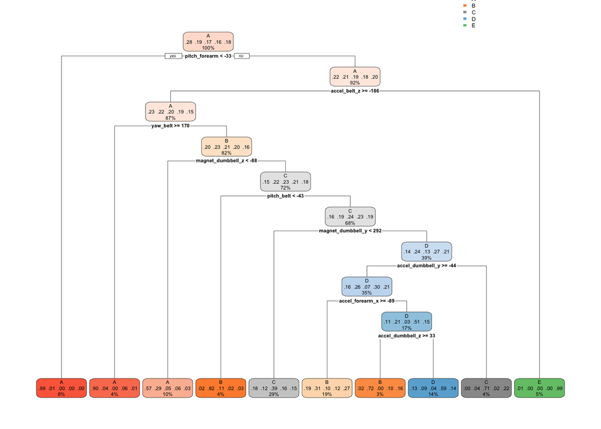

```r
rpart.plot(modfitrp$finalModel)
```

### 2. Random Forest

```r
set.seed(33223)
modfitrf<-train(classe~.,method='rf',data=traindatatrain,ntree=100)
predictrf<-predict(modfitrf,traindatatest)
rfconfmat<-confusionMatrix(predictrf,traindatatest$classe)
rfconfmat
```

```
## Confusion Matrix and Statistics
##
##           Reference
## Prediction    A    B    C    D    E
##          A 2228   13    0    0    0
##          B    4 1499   12    0    0
##          C    0    5 1348   16    1
##          D    0    0    8 1267    6
##          E    0    1    0    3 1435
##
## Overall Statistics
##
##                Accuracy : 0.9912
##                  95% CI : (0.9889, 0.9932)
##     No Information Rate : 0.2845
##     P-Value [Acc > NIR] : < 2.2e-16
##
##                   Kappa : 0.9889
##
##  Mcnemar's Test P-Value : NA
##
## Statistics by Class:
##
##                      Class: A Class: B Class: C Class: D Class: E
## Sensitivity            0.9982   0.9875   0.9854   0.9852   0.9951
## Specificity            0.9977   0.9975   0.9966   0.9979   0.9994
## Pos Pred Value         0.9942   0.9894   0.9839   0.9891   0.9972
## Neg Pred Value         0.9993   0.9970   0.9969   0.9971   0.9989
## Prevalence             0.2845   0.1935   0.1744   0.1639   0.1838
## Detection Rate         0.2840   0.1911   0.1718   0.1615   0.1829
## Detection Prevalence   0.2856   0.1931   0.1746   0.1633   0.1834
## Balanced Accuracy      0.9979   0.9925   0.9910   0.9915   0.9973
```

We see that the accuracy using this model is 0.9912057. Plot for the Random Forest prediction model.

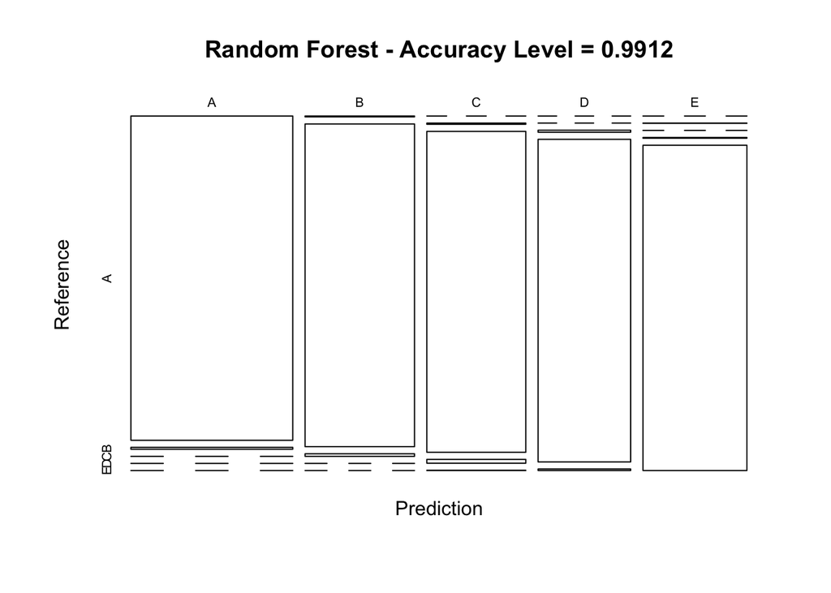

```r
plot(rfconfmat$table, col = rfconfmat$byClass,
     main = paste("Random Forest - Accuracy Level =",
                  round(rfconfmat$overall['Accuracy'], 4)))
```

### 3. Gradient Boosting Machine

```r
set.seed(33224)
modfitgbm<-train(classe~.,method='gbm',data=traindatatrain,verbose=FALSE)
predictgbm<-predict(modfitgbm,traindatatest)
gbmconfmat<-confusionMatrix(predictgbm,traindatatest$classe)
gbmconfmat
```

```
## Confusion Matrix and Statistics
##
##           Reference
## Prediction    A    B    C    D    E
##          A 2199   47    0    0    2
##          B   24 1430   46    6   25
##          C    6   36 1303   48   10
##          D    2    1   17 1220   24
##          E    1    4    2   12 1381
##
## Overall Statistics
##
##                Accuracy : 0.9601
##                  95% CI : (0.9555, 0.9643)
##     No Information Rate : 0.2845
##     P-Value [Acc > NIR] : < 2.2e-16
##
##                   Kappa : 0.9495
##
##  Mcnemar's Test P-Value : 3.786e-09
##
## Statistics by Class:
##
##                      Class: A Class: B Class: C Class: D Class: E
## Sensitivity            0.9852   0.9420   0.9525   0.9487   0.9577
## Specificity            0.9913   0.9840   0.9846   0.9933   0.9970
## Pos Pred Value         0.9782   0.9340   0.9287   0.9652   0.9864
## Neg Pred Value         0.9941   0.9861   0.9899   0.9900   0.9905
## Prevalence             0.2845   0.1935   0.1744   0.1639   0.1838
## Detection Rate         0.2803   0.1823   0.1661   0.1555   0.1760
## Detection Prevalence   0.2865   0.1951   0.1788   0.1611   0.1784
## Balanced Accuracy      0.9882   0.9630   0.9685   0.9710   0.9774
```

We see that the accuracy using this model is 0.9601071. Plot for the Gradient Boosting Machine prediction model.

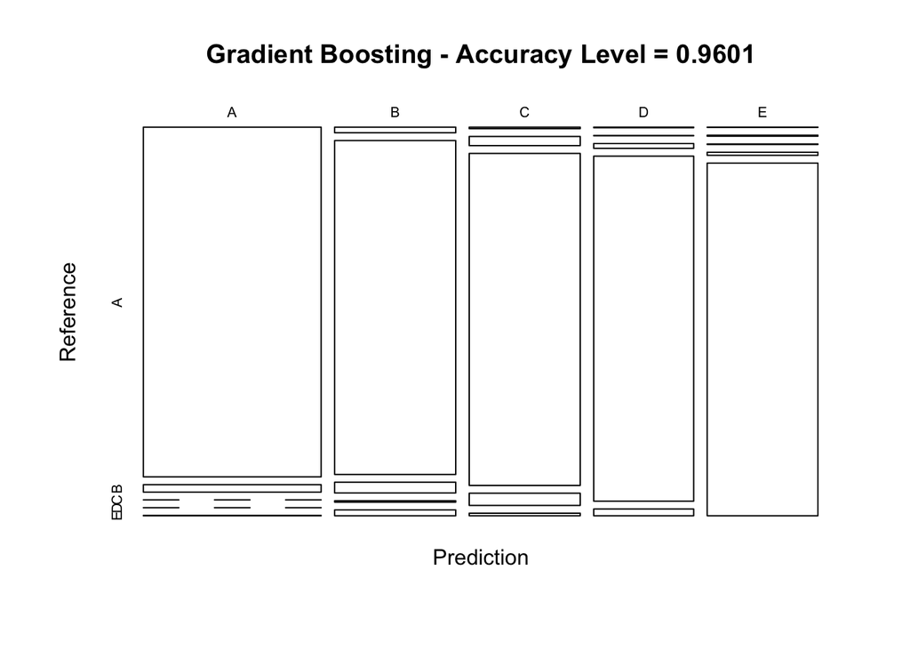

```r
plot(gbmconfmat$table, col = gbmconfmat$byClass,
     main = paste("Gradient Boosting - Accuracy Level =",
                  round(gbmconfmat$overall['Accuracy'], 4)))
```

# Conclusion and Test Data Prediction

We can see that the accuracy on the cross-validation data is better with Random forest model. We will use it for prediction on the testing data.

```r
predict(modfitrf,testdata)
```

```
##  [1] B A B A A E D B A A B C B A E E A B B B
## Levels: A B C D E
```